# LM Sheet 3

We continue with salary data frame from problem sheet 2.

```r
salary <- read.table(file="C:/Users/Dom/Documents/GitHub/Stats Work/Year 3/Linear Models/salary.dat", header=TRUE) #read in data in .dat format
head(salary) #view first six entries of salary
```

|  | sx | rk | yr | dg | yd | sl |
| --- | --- | --- | --- | --- | --- | --- |
| 1 | male | full | 25 | doctorate | 35 | 36350 |
| 2 | male | full | 13 | doctorate | 22 | 35350 |
| 3 | male | full | 10 | doctorate | 23 | 28200 |
| 4 | female | full | 7 | doctorate | 27 | 26775 |
| 5 | male | full | 19 | masters | 30 | 33696 |
| 6 | male | full | 16 | doctorate | 21 | 28516 |

1. Regress log(sl) instead of sl on sx and interpret the coefficient of female.

```r
lm(log(sl) ~ sx, data = salary)
```

```
Call:
lm(formula = log(sl) ~ sx, data = salary)

Coefficients:
(Intercept)       sxmale
     9.9359       0.1524
```

2. Fit the linear model (say, lsdy.fit) log(sli) = ??0 + ??1sxi + ??2dgi + ??3ydi + ??4dgiydi + ??i Describe the combined effects of dg and yd, and the effect of sx on salary (not on logsalary). Is there evidence of sex discrimination according to this model? Do we still need the interaction term?

```r
lsdy.fit <- lm(log(sl) ~ sx + dg + yd +dg*yd, data = salary)
lsdy.fit
```

```
Call:
lm(formula = log(sl) ~ sx + dg + yd + dg * yd, data = salary)

Coefficients:
 (Intercept)        sxmale     dgmasters            yd  dgmasters:yd
     9.63921       0.08398       0.22851       0.02613      -0.01942
```

3. Compute the jack-knifed residuals and plot them against fitted values from lsdy.fit. Compare the plot for log-salary with the original plot for salary in dollars. Comment on any observations with jack-knifed residuals exceeding two in absolute value.

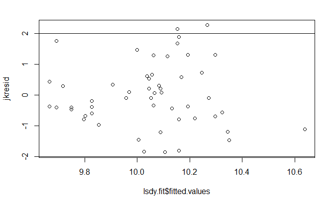

```r
library(MASS)
jkresid <- studres(lsdy.fit) #calculate jack-knifed residuals
plot(lsdy.fit$fitted.values, jkresid) #plot against fitted values
abline(a=-2, b=0); abline(a=2, b=0);
```

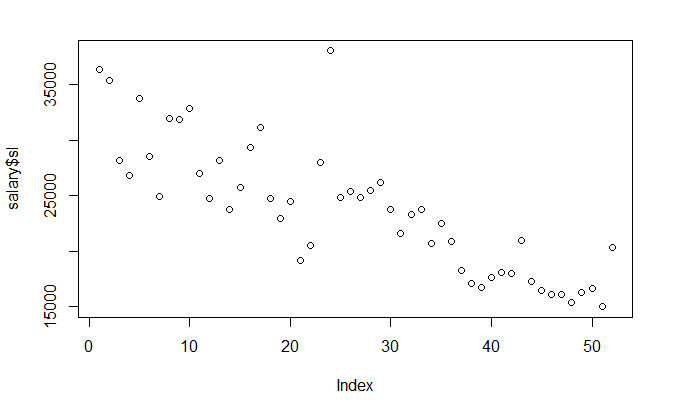

```r
plot(salary$sl) #plot salary
```

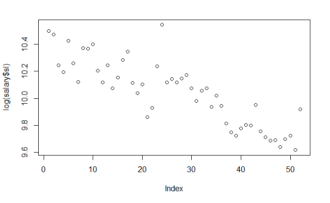

```r
plot(log(salary$sl)) #plot log-salary
```

The log-salary plot appears to follow a straight line better than the salary plot, suggesting our transformation is apt.

There are 2 observations with jack-knifed residuals greater than 2 in absolute value. These may have undue influence on the model fit and should be investigated further, potentially for omission.

4. Compute the leverages and Cook’s distances and list any noteworthy observations. How do the leverages for this model compare with sdy.fit? Has the log transformation helped moderate the actual influence of some observations?

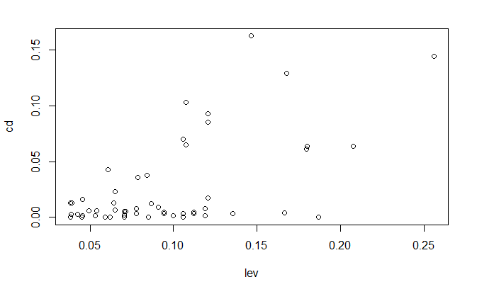

```r
lev <- hatvalues(lsdy.fit) #leverage
cd <- cooks.distance(lsdy.fit) #cook's distance
plot(lev, cd)
```

Compared to the previous model (sheet 2), there appears to be similar leverage and lower cook’s distance, suggesting the log transform has reduced the influence of some observations.

5. Plot log-salary against a measure of qualifications and experience based on lsdy.fit, and compare your results with that obtained from sdy.fit.

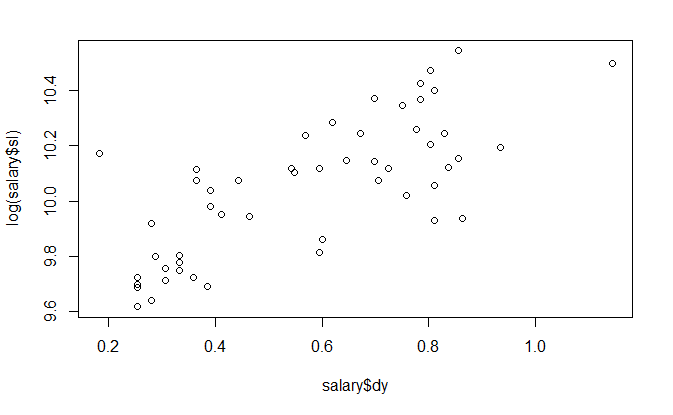

```r
salary$dy <- (salary$dg =="doctorate") * 0.22850653 + salary$yd * 0.02613256
plot(salary$dy, log(salary$sl))
```

6. Re-fit the model (1) omitting the observation with the largest Cook’s distance. What happens to the sex differential controlling for dg and yd if we omit this case? What other coefficients are affected?

```r
which(cd == max(cd)) #find observation with largest cd
```

```
24
24
```

```r
salary1 <- salary[-24,] #create new frame without observation 24
lsdy.fit1 <- lm(log(sl) ~ sx + dg + yd +dg*yd, data = salary1) #regress model
lsdy.fit1
```

```
Call:
lm(formula = log(sl) ~ sx + dg + yd + dg * yd, data = salary1)

Coefficients:
 (Intercept)        sxmale     dgmasters            yd  dgmasters:yd
     9.63000       0.11216       0.20673       0.02451      -0.01741
```

sxmale, the sex differential controlled, increases. The other coefficients do not change much.

7. The model (1) relies on the assumption that the combined effects on (log) salary of qualification and experience are the same for men and women. Test this assumption using an F-test including all observations. Do you think your conclusion would change if you excluded the most influential observation?

Test H0: log(sl) ~ sx + dg + yd + dg*yd H1: log(sl) ~ sx + dg + yd + dg*yd + dg*yd*sx

```r
lsdy.fit2 <- lm(log(sl) ~ sx + dg + yd + dg*yd + dg*yd*sx, data = salary) #fit alternative model
anova(lsdy.fit, lsdy.fit2) #perform f-test
```

```
Analysis of Variance Table

Model 1: log(sl) ~ sx + dg + yd + dg * yd
Model 2: log(sl) ~ sx + dg + yd + dg * yd + dg * yd * sx
  Res.Df     RSS Df Sum of Sq      F Pr(>F)
1     47 0.91314
2     44 0.89637  3  0.016765 0.2743 0.8436
```

Our p-value is not significant here, so accept null hypothesis that the mixed effect of qualification and experience is sex-neutral.

The p-value is sufficiently large that removing one observation would not change the conclusion, regardless of influence.

8. Check that taking logs was a good idea by trying Box-Cox transformations in the range (???2, 2) and plotting the profile log-likelihood for the model with sx, dg, yd and dg*yd. You may use the function boxcox from the R package MASS. Did we need to transform the data? Was the natural logarithm a good transformation?

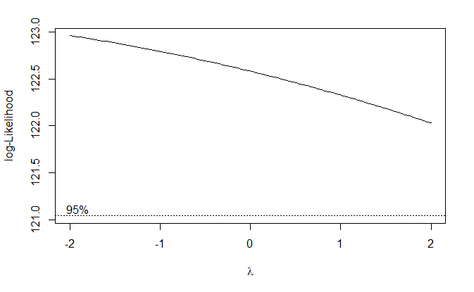

```r
bc <- boxcox(lsdy.fit, lambda = seq(-2, 2, length.out=10))
```

This is maximised outside the range (-2,2) so the transform is not justified.

///////////////////////////////////////////////////////////